# Time Series HW2

B082040005 高念慈

2023-03-09

## 1.

Consider the daily stock returns of American Express (AXP),  
Caterpillar (CAT), and Starbucks (SBUX) from January 01, 2020 to  
February 10, 2023. The price data can be obtained by using R package quantmod.

```r
getSymbols("AXP",from="2020-01-01",to='2023-02-11')
```

```
## [1] "AXP"
```

```r
getSymbols("CAT",from="2020-01-01",to='2023-02-11')
```

```
## [1] "CAT"
```

```r
getSymbols("SBUX",from="2020-01-01",to='2023-02-11')
```

```
## [1] "SBUX"
```

d.Test the null hypothesis that the mean of the log returns of each stock is zero.  
That is, perform three separate tests.  
Use 5% significance level to draw your conclusion.  
( You can use R function t.test() to answer the problem. )

### 取出 adjust price

```r
AXP_adjust = AXP[,6]
CAT_adjust = CAT[,6]
SBUX_adjust = SBUX[,6]
```

- $r_t = ln(R_t + 1)$
- $r_t = ln(P_t) - ln(P_{t-1})$
- $R_t = e^{r_t}-1$
- simple returns : $R_t$
- log returns : $r_t$
- $R_t = \frac{P_{t}-P_{t-1}}{P_{t-1}}$

### Log Return in percentages

```r
# Log Return : r_t = ln(P_t) - ln(P_{t-1})

AXP_log_returns = diff(log(AXP_adjust))*100
head(AXP_log_returns)
```

```
##            AXP.Adjusted
## 2020-01-02           NA
## 2020-01-03   -0.9982096
## 2020-01-06   -0.4343222
## 2020-01-07   -0.5253129
## 2020-01-08    1.7112254
## 2020-01-09    1.7920356
```

```r
CAT_log_returns = diff(log(CAT_adjust))*100
head(CAT_log_returns)
```

```
##            CAT.Adjusted
## 2020-01-02           NA
## 2020-01-03  -1.39816025
## 2020-01-06  -0.06737079
## 2020-01-07  -1.33009612
## 2020-01-08   0.88419401
## 2020-01-09  -0.25087727
```

```r
SBUX_log_returns = diff(log(SBUX_adjust))*100
head(SBUX_log_returns)
```

```
##            SBUX.Adjusted
## 2020-01-02            NA
## 2020-01-03    -0.5836614
## 2020-01-06    -0.7911451
## 2020-01-07    -0.3068309
## 2020-01-08     1.1542541
## 2020-01-09     1.8394018
```

### t.test()

```r
# AXP_log_returns
t.test(as.vector(AXP_log_returns))
```

```
##
##  One Sample t-test
##
## data:  as.vector(AXP_log_returns)
## t = 0.50358, df = 782, p-value = 0.6147
## alternative hypothesis: true mean is not equal to 0
## 95 percent confidence interval:
##  -0.1465192  0.2476335
## sample estimates:
##  mean of x
## 0.05055716
```

```r
# p-value = 0.6147 not reject H0，the mean of the log returns is zero
# 95 percent confidence interval : -0.1465192  0.2476335

# CAT_log_returns
t.test(as.vector(CAT_log_returns))
```

```
##
##  One Sample t-test
##
## data:  as.vector(CAT_log_returns)
## t = 0.92575, df = 782, p-value = 0.3549
## alternative hypothesis: true mean is not equal to 0
## 95 percent confidence interval:
##  -0.08246385  0.22966230
## sample estimates:
##  mean of x
## 0.07359923
```

```r
# p-value = 0.3549 not reject H0，the mean of the log returns is zero
# 95 percent confidence interval : -0.08246387  0.22966233

# SBUX_log_returns
t.test(as.vector(SBUX_log_returns))
```

```
##
##  One Sample t-test
##
## data:  as.vector(SBUX_log_returns)
## t = 0.39353, df = 782, p-value = 0.694
## alternative hypothesis: true mean is not equal to 0
## 95 percent confidence interval:
##  -0.1255052  0.1884440
## sample estimates:
## mean of x
## 0.0314694
```

```r
# p-value = 0.694 not reject H0，the mean of the log returns is zero
# 95 percent confidence interval : -0.1255052  0.1884439
```

## **錯:Use 5% significance level to draw your conclusion**

## **錯:NOT in percentages!!**

## **改:額外寫出來!!&不要亂換百分比!!**

### draw

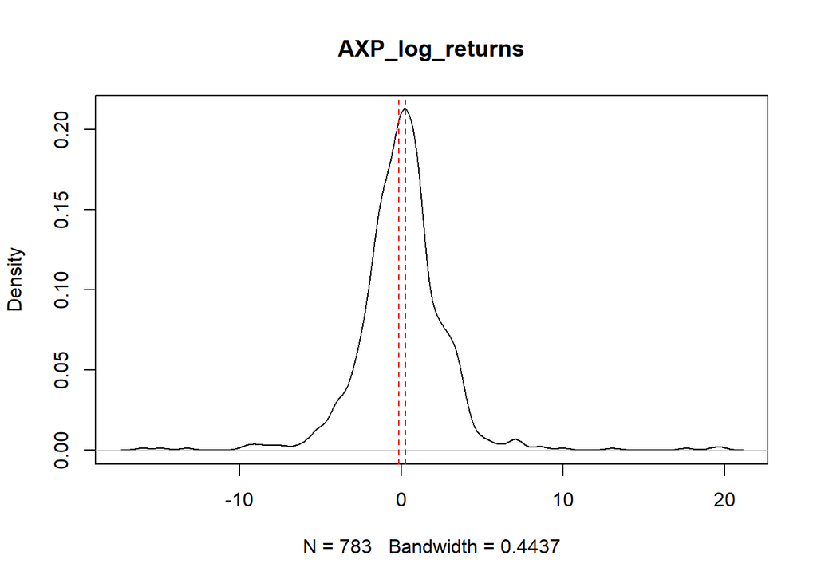

```r
# AXP_log_returns
plot(density(as.vector(AXP_log_returns),na.rm = T),main = "AXP_log_returns")
abline(v = c(-0.1465192,0.2476335),col=c("red","red"),lty=2,lwd=1)
```

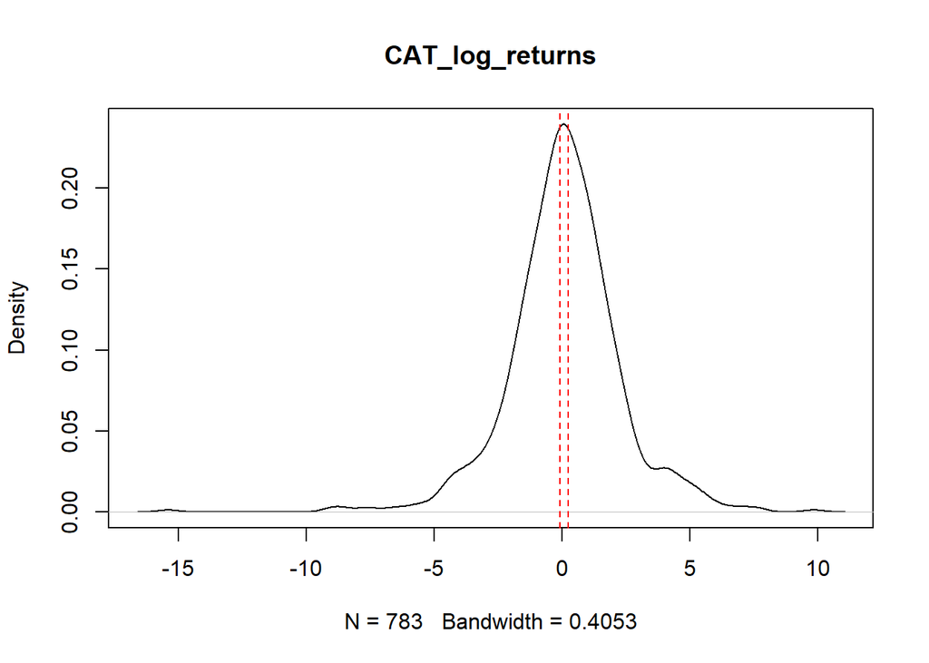

```r
# CAT_log_returns
plot(density(as.vector(CAT_log_returns),na.rm = T),main = 'CAT_log_returns')
abline(v = c(-0.08246387,0.22966233),col=c("red","red"),lty=2,lwd=1)
```

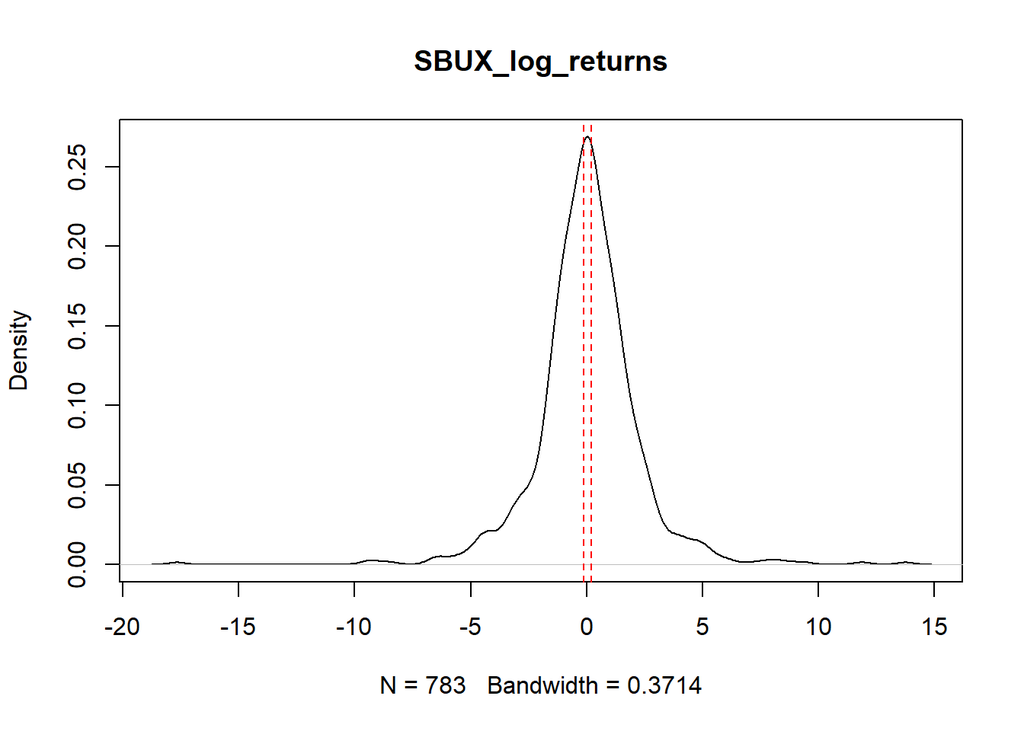

```r
# SBUX_log_returns
plot(density(as.vector(SBUX_log_returns),na.rm = T),main = "SBUX_log_returns")
abline(v = c(-0.1255052,0.1884439),col=c("red","red"),lty=2,lwd=1)
```

## 2.

Consider the monthly stock returns for General Motors (GM), CRSP value-weighted  
index (VW), CRSP equal weighted index (EW), and S&P composite index  
from January 1975 to December 2008.  
The returns of the indexes include dividend distributions.  
Data file is m-gm3dx7508.txt (date, gm, vw, ew, sp).

### 月度簡單回報

```r
da = read.table("https://faculty.chicagobooth.edu/-/media/faculty/ruey-s-tsay/teaching/fts3/m-gm3dx7508.txt",header = T)
head(da)
```

```
##       date       gm       vw       ew       sp
## 1 19750131 0.252033 0.141600 0.299260 0.122812
## 2 19750228 0.028571 0.058411 0.053918 0.059886
## 3 19750331 0.054487 0.030191 0.081497 0.021694
## 4 19750430 0.045593 0.046497 0.031093 0.047265
## 5 19750530 0.037209 0.055140 0.072876 0.044101
## 6 19750630 0.107955 0.051473 0.071792 0.044323
```

d.Test the null hypothesis that the mean of the log returns of each stock is zero.  
That is, perform three separate tests.  
Use 5% significance level to draw your conclusion.

- $r_t = ln(R_t + 1)$

### Log Return in percentages

```r
# Log Return : r_t = ln(R_t + 1)*100

a = da[,c("gm","vw","ew","sp")]
log_returns = log(a + 1)*100
head(log_returns)
```

```
##          gm        vw        ew        sp
## 1 22.476863 13.243079 26.179487 11.583625
## 2  2.817046  5.676873  5.251465  5.816136
## 3  5.305439  2.974422  7.834619  2.146203
## 4  4.458419  4.544840  3.061940  4.618200
## 5  3.653345  5.367346  7.034289  4.315623
## 6 10.251597  5.019204  6.933201  4.336883
```

### t.test()

```r
# "gm"
t.test(log_returns[,"gm"])
```

```
##
##  One Sample t-test
##
## data:  log_returns[, "gm"]
## t = 0.23206, df = 407, p-value = 0.8166
## alternative hypothesis: true mean is not equal to 0
## 95 percent confidence interval:
##  -0.8231636  1.0435276
## sample estimates:
## mean of x
##  0.110182
```

```r
# p-value = 0.8166 not reject H0，the mean of the log returns is zero
# 95 percent confidence interval : -0.8231636  1.0435276

# "vw"
t.test(log_returns[,"vw"])
```

```
##
##  One Sample t-test
##
## data:  log_returns[, "vw"]
## t = 4.0064, df = 407, p-value = 7.332e-05
## alternative hypothesis: true mean is not equal to 0
## 95 percent confidence interval:
##  0.4607213 1.3484127
## sample estimates:
## mean of x
##  0.904567
```

```r
# p-value = 7.332e-05 reject H0，the mean of the log returns is not zero
# 95 percent confidence interval : 0.4607213 1.3484127

# "ew"
t.test(log_returns[,"ew"])
```

```
##
##  One Sample t-test
##
## data:  log_returns[, "ew"]
## t = 4.1899, df = 407, p-value = 3.425e-05
## alternative hypothesis: true mean is not equal to 0
## 95 percent confidence interval:
##  0.6194647 1.7145293
## sample estimates:
## mean of x
##  1.166997
```

```r
# p-value = 3.425e-05 reject H0，the mean of the log returns is not zero
# 95 percent confidence interval : 0.6194647 1.7145293

# "sp"
t.test(log_returns[,"sp"])
```

```
##
##  One Sample t-test
##
## data:  log_returns[, "sp"]
## t = 2.8996, df = 407, p-value = 0.003939
## alternative hypothesis: true mean is not equal to 0
## 95 percent confidence interval:
##  0.2035053 1.0603692
## sample estimates:
## mean of x
## 0.6319372
```

```r
# p-value = 0.003939 reject H0，the mean of the log returns is not zero
# 95 percent confidence interval : 0.2035053 1.0603692
```

```r
apply(log_returns,2,t.test)   # t.test
```

```
## $gm
##
##  One Sample t-test
##
## data:  newX[, i]
## t = 0.23206, df = 407, p-value = 0.8166
## alternative hypothesis: true mean is not equal to 0
## 95 percent confidence interval:
##  -0.8231636  1.0435276
## sample estimates:
## mean of x
##  0.110182
##
##
## $vw
##
##  One Sample t-test
##
## data:  newX[, i]
## t = 4.0064, df = 407, p-value = 7.332e-05
## alternative hypothesis: true mean is not equal to 0
## 95 percent confidence interval:
##  0.4607213 1.3484127
## sample estimates:
## mean of x
##  0.904567
##
##
## $ew
##
##  One Sample t-test
##
## data:  newX[, i]
## t = 4.1899, df = 407, p-value = 3.425e-05
## alternative hypothesis: true mean is not equal to 0
## 95 percent confidence interval:
##  0.6194647 1.7145293
## sample estimates:
## mean of x
##  1.166997
##
##
## $sp
##
##  One Sample t-test
##
## data:  newX[, i]
## t = 2.8996, df = 407, p-value = 0.003939
## alternative hypothesis: true mean is not equal to 0
## 95 percent confidence interval:
##  0.2035053 1.0603692
## sample estimates:
## mean of x
## 0.6319372
```

GM:  
p-value = 0.8166 > 0.05 $\implies$ non-reject $H_0 : \bar{X}_{gm} = 0$ $\implies$ The mean of the log returns of GM stock is equal to zero

VW:  
p-value = 7.332e-05 < 0.05 $\implies$ reject $H_0 : \bar{X}_{vw} = 0$ $\implies$ The mean of the log returns of VW stock is not equal to zero

EW:  
p-value = 3.425e-05 < 0.05 $\implies$ reject $H_0 : \bar{X}_{ew} = 0$ $\implies$ The mean of the log returns of EW stock is not equal to zero

S&P:  
p-value = 0.003939 < 0.05 $\implies$ reject $H_0 : \bar{X}_{sp} = 0$ $\implies$ The mean of the log returns of S&P stock is not equal to zero

### draw

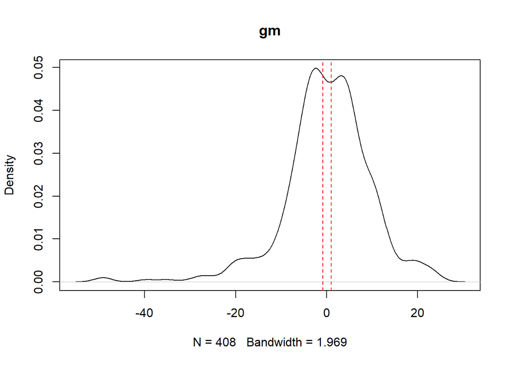

```r
# "gm"
plot(density(log_returns[,"gm"],na.rm = T),main = "gm")
abline(v = c(-0.8231636, 1.0435276),col=c("red","red"),lty=2,lwd=1)
```

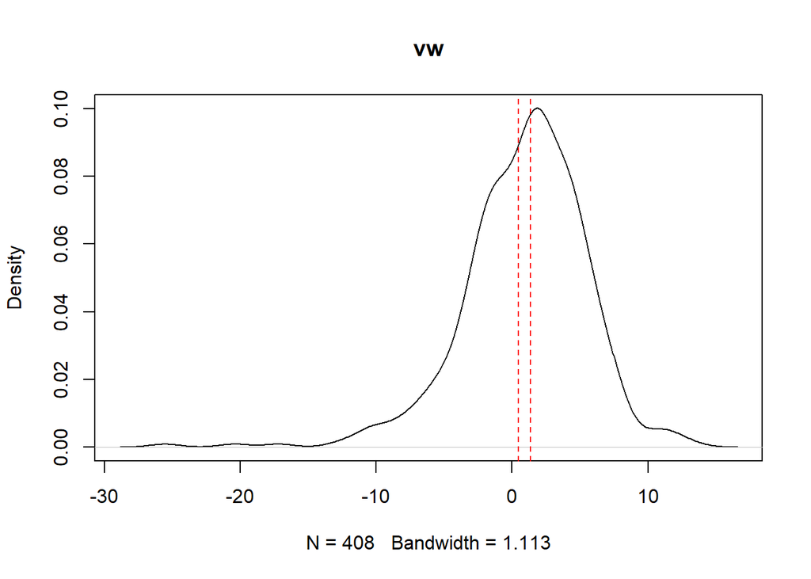

```r
# "vw"
plot(density(log_returns[,"vw"],na.rm = T),main = "vw")
abline(v = c(0.4607213, 1.3484127),col=c("red","red"),lty=2,lwd=1)
```

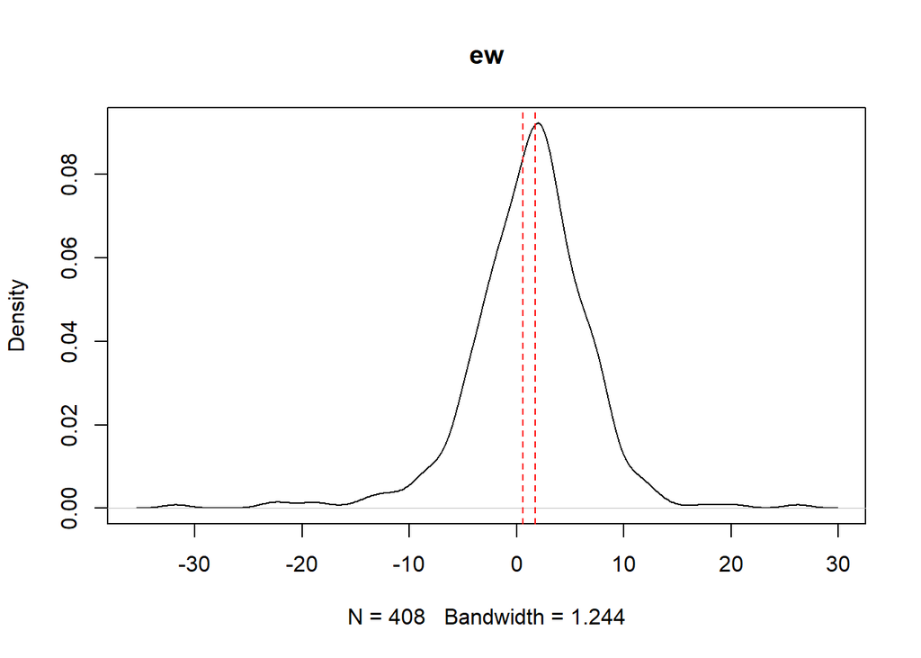

```r
# "ew"
plot(density(log_returns[,"ew"],na.rm = T),main = "ew")
abline(v = c(0.6194647, 1.7145293),col=c("red","red"),lty=2,lwd=1)
```

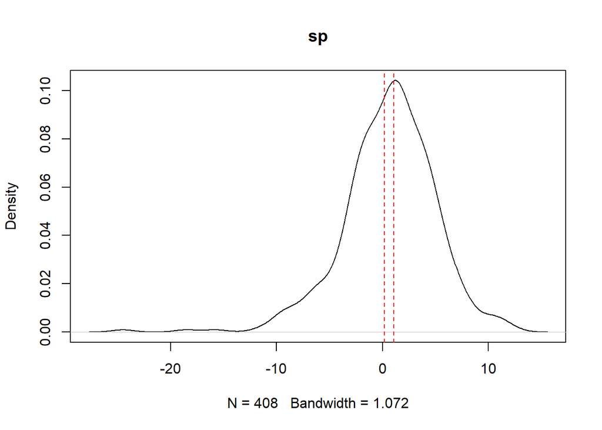

```r
# "sp"
plot(density(log_returns[,"sp"],na.rm = T),main = "sp")
abline(v = c(0.2035053, 1.0603692),col=c("red","red"),lty=2,lwd=1)
```